# Preliminary Results

Camila Vargas e Ignacia Rivera

19 de octubre de 2018

## Overview

Up to date we have collected most of the raw data available needed for the analysis of this project. We have been working on cleaning these databases. We are in the process of cleaning the imports and export data, therfore the information presented in this report on imports and exports it is based on a third party report rather than the raw data it self. This report present preliminary results we have found so far.

## Total amount of fish landed, produced in aquaculture, Imported, Exported, for the last 5 years.

[output not shown]

```r
## Landing, harvest and exports data in one dataframe


##Totals landings, harvest and exports (tons) per year (2013-2017)

table_totals <- landings_total_yr %>%
  left_join(harvest_total_yr, by = "year") %>%
  left_join(exports_total_yr_IFOP, by = "year") %>%
  rename(total_exports = exports)


kable(table_totals, "latex", caption = "Total amount of landings, aquaculture harvest and exports (tons) in Chile in the last 5 years", booktabs = T) %>%
kable_styling(latex_options = c("hold_position"))
```

[output not shown]

## Ten most important fisheries in terms of landing and harvest

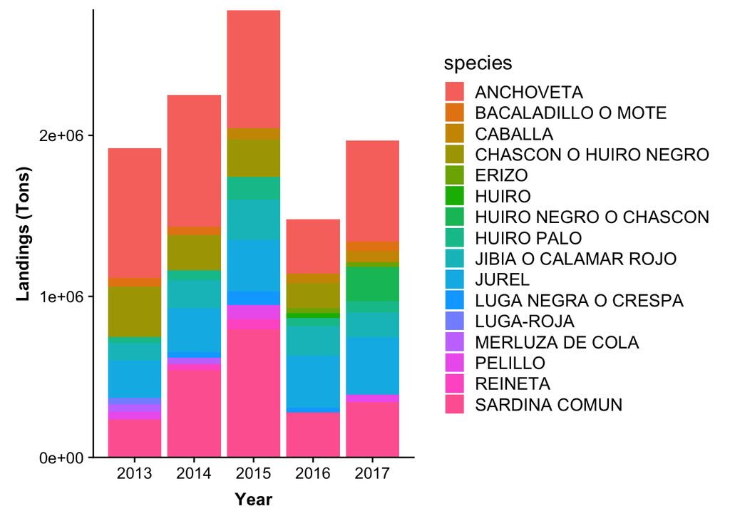

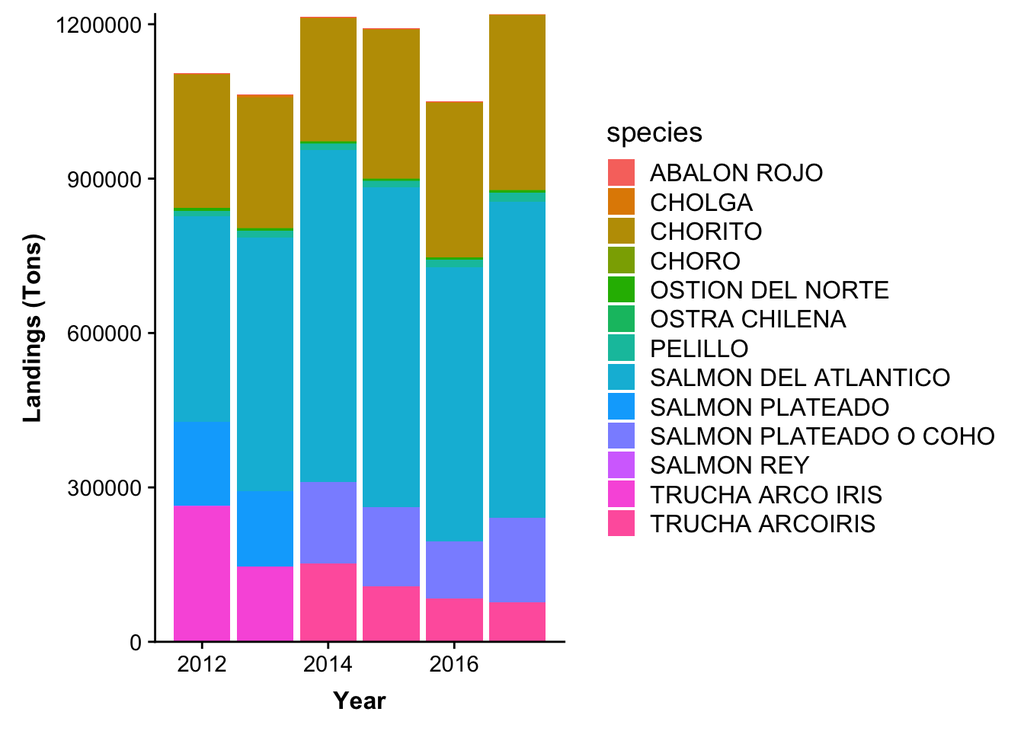

[figure not shown]

```r
## ploting them together

plot_grid(top10_catch, top10_harvest, labels = c("A", "B"))
```

## Top domestic marine, capture fisheries based on employment

### *Artisanal sector*

By 2017, there were 80,056 artisanal fishers officially registered along with 11,819 vessels (@maturana_mujeres_2017). The number of women participating in the artisanal sector has been increasing and currently 23% of the registered fishers are women. Artisanal fishers are requiered to register in the official record known as RPA (by its acronym in spanish). The RPA holds information regarding the gender, date of birth, location and type of activities performed by each fisher (e.i. diver, fisher, boat owner, shore gatherer). Although detailed, the RPA does not provide information on the specific species targeted by each fisher. Thus, we cannot determine the contribution of particular species to artisanal fishers livelihoods. Nontheless, we can combine information from the RPA with other data to get estimates.

**Figure 1** shows the number of fishers in each region that perform a particular activity based on the 2018 RPA for women (upper panel) and men. Different activities are associated to different groups of species; fishers usually target pelagic and demersal species, divers target mostly benthic species, while gatherers tend to collect and harvest algae. This give us an idea of the groups of species that are more important in terms of employment in each region and for each gender. We see that in general, women mostly participate in the extraction of algae while men tend to rely on multiple group of species as sources of employment. *We can do trends for this and split it by gender, but we first need to double check with SERNAPESCA some of these numbers that are too large to be realistic.*

*We have asked for data on species-specific permits or quotas for each fisher or vessel. If available, we could get a more precise estimate of the contirbution of particular fisheries to employment in the extractive artisanal sector.*

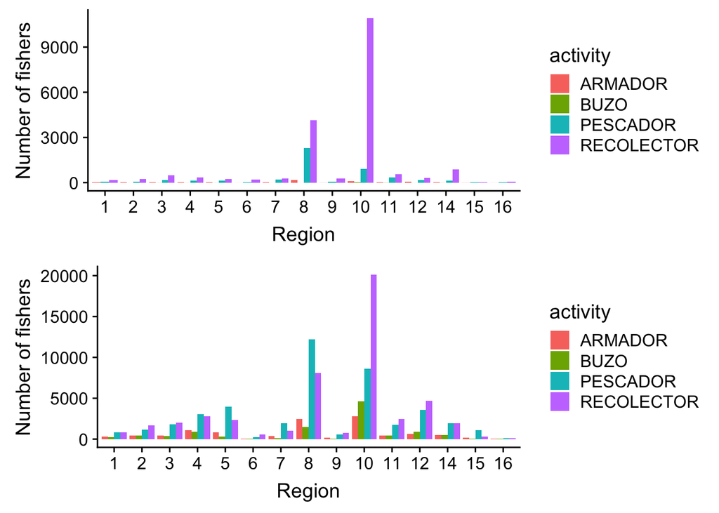

Number of fishers participating in different activities in each Chilean region based RPA 2018, provided by SERNAPESCA. The upper panel refers to women while the panel below to men. A single fisher can be register under multiple activities.

The artisanal sector generates employment beyond the extraction stage. After extraction, most resources are directly selled by the fishers in commercial facilities near their landing points, some are selled to local restaurants *Here we want to include a figure with the value chain of the artisanal catch and hopefully find a way to estimate the contirbution of different group of species to employment in different stages of the value process*

### Industrial sector

For the industrial sector, SERNAPESCA holds records only on the number of boats and its owners. There are currently 472 industrial vessels owned by 164 different companies based on official registers. Estimates from SUBPESCA indicate that the overall operation of industrial vessels provide around 3,500 jobs nationwide (@subpesca_pesca_2018).

*We have asked for data on species-specific landings or quotas for each industrial vessel. Using this data we will be able to assess how much each vessel has depended on particular species during the past years. We will use the size of the vessel as a proxy for how many people operate in it. Combining this two pieces of information we expect to have an estimate of how relevant are specific fisheries in providing job positions in the extractive industrial sector.*

Most of the catch from the industrial sector ends up going to processing facilities where it is transformed in products for domestic consumption, exportation or as supplies for the aquaculture industry.

SERNAPESCA holds records on the self-reported number of permanent and temporal jobs in each facility. There were 7,751 permanent job positions and another 1,233 temporal positions in processing facilities in 2017. *We can do trends for this and split it by gender, but we first need to double check with SERNAPESCA some of these numbers that are too large to be realistic.*

*To assess the contirbution of specific fisheries to employment in processing facilities we will use data we already have on (i) the production lines of each facility (e.g. fish meal, canned products, smoked products), (ii) tons of each species use to produce different products (e.g. fish meal, canned products, smoked products) in each region, (iii) the region in which each facility is located, (iv) the number of people working in each facility.*